# Mélodie Enigmatique

## Qualité des représentations

[interactive chart not shown]

## Etude du premier axe

- Contributions
- tableau des contributions

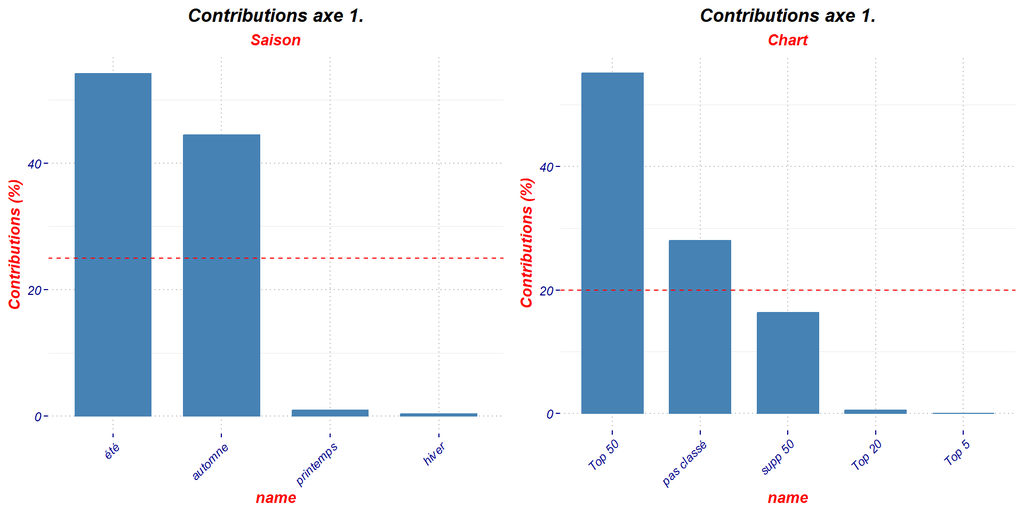

|  | été | automne | printemps | hiver |
| --- | --- | --- | --- | --- |
| Contribution | 54.2 | 44.5 | 1.0 | 0.4 |
| Cumulée | 54.2 | 98.6 | 99.6 | 100.0 |

**Profils lignes**

|  | Top 50 | pas classé | supp 50 | Top 20 | Top 5 |
| --- | --- | --- | --- | --- | --- |
| Contribution | 55.1 | 28 | 16.4 | 0.6 | 0 |
| Cumulée | 55.1 | 83 | 99.4 | 100.0 | 100 |

## Etude du second axe

- Contributions
- tableau des contributions

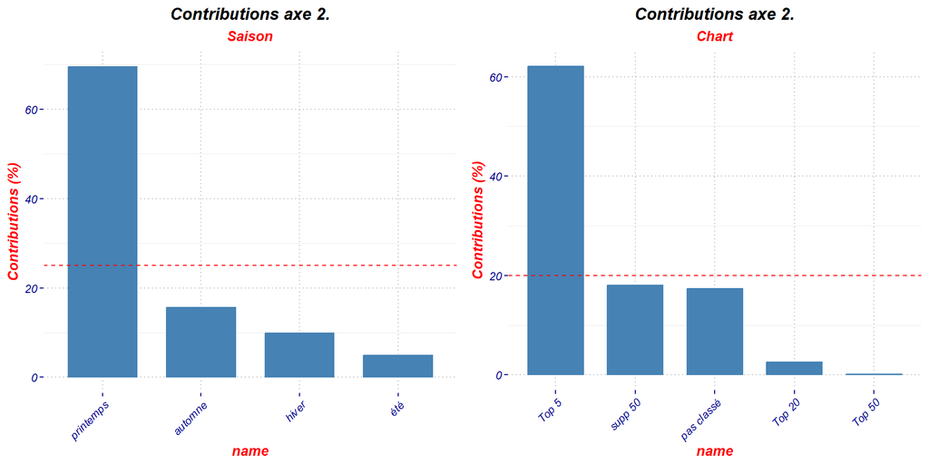

**Profils colonnes**

|  | printemps | automne | hiver | été |
| --- | --- | --- | --- | --- |
| Contribution | 69.5 | 15.6 | 9.9 | 4.9 |
| Cumulée | 69.5 | 85.2 | 95.1 | 100.0 |

**Profils lignes**

|  | Top 5 | supp 50 | pas classé | Top 20 | Top 50 |
| --- | --- | --- | --- | --- | --- |
| Contribution | 62.1 | 18.0 | 17.3 | 2.5 | 0.1 |
| Cumulée | 62.1 | 80.1 | 97.4 | 99.9 | 100.0 |

# ACM :

## Objectifs :

- Avoir une vue d’ensemble de nos musiques
- Déterminer la pseudo-musique moyenne
- Déterminer les musiques très hétérogènes
- Pourquoi sont-elles hétérogènes ?
- Détecter une association entre la popularité d’une musique et ses caractéristiques musicales

## Codage des variables

- La tonalité :

```r
df <- df |>
  mutate(tonalite = case_when(key %in% c("C","C#","D","D#")~"registre grave",
                              key %in% c("E","F","F#","G")~"registre moyen",
                              key %in% c("A","A#","B","G#")~"registre aigu",
                              TRUE~"registre ?"),.after = key) |>
  select(everything())
```

- L’indice des caractéristiques musicales

```r
normaliserx100 <- function(x){
  round(((x-min(x))/(max(x)-min(x)))*100,4)
}

df <-  df |>
  mutate(across(c(ends_with("percent"),streams),normaliserx100,.names = "{.col}_normx100")) |>
  select(everything())

df <- df |>
  mutate(across(ends_with("percent_normx100"),~case_when(.>=75~4,
                                                .>=50~3,
                                                .>=25~2,
                                               TRUE~1),.names = "ind_{.col}")) |>
  mutate(across(starts_with("ind_"),as.factor)) |>
  select(everything())




colnames(df)[46] <- "speechiness"
colnames(df)[45] <- "liveness"
colnames(df)[44] <- "instrumentalness"
colnames(df)[43] <- "acousticness"
colnames(df)[42] <- "energy"
colnames(df)[41] <- "valence"
colnames(df)[40] <- "danceability"
```

**Répartition des musiques parmi les variables actives**

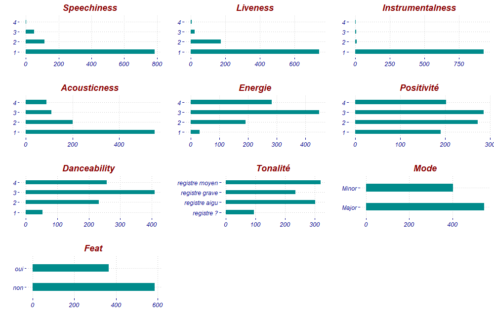

## Inertie des dimensions :

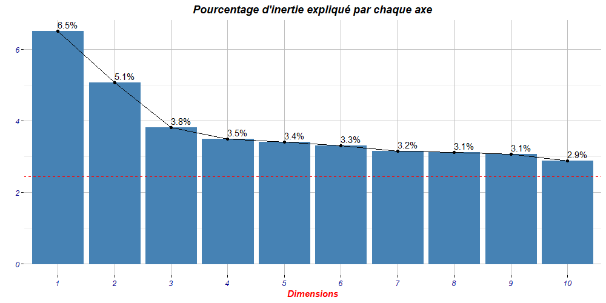

- Conservation des axes $F_{i}$ (avec $i = (1,2,3)$) portant 15.39% de l’inertie totale
- 6.5% de l’inertie est expliquée par l’axe factoriel $F_{1}$.

## Etude des variables

- Nuage des modalités
- Contribution axe 1
- Contribution axe 2
- $\eta^2$ des variables actives

**plan(1,2)**

[interactive chart not shown]

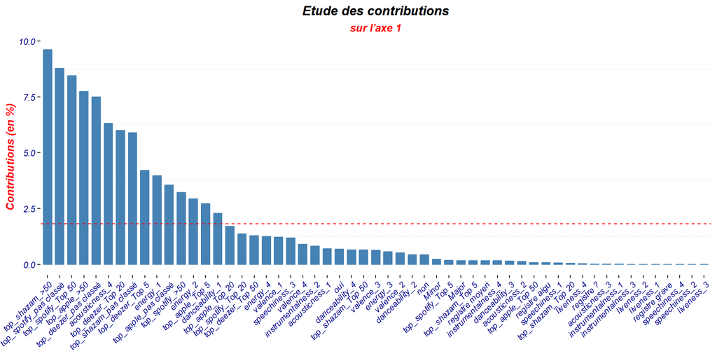

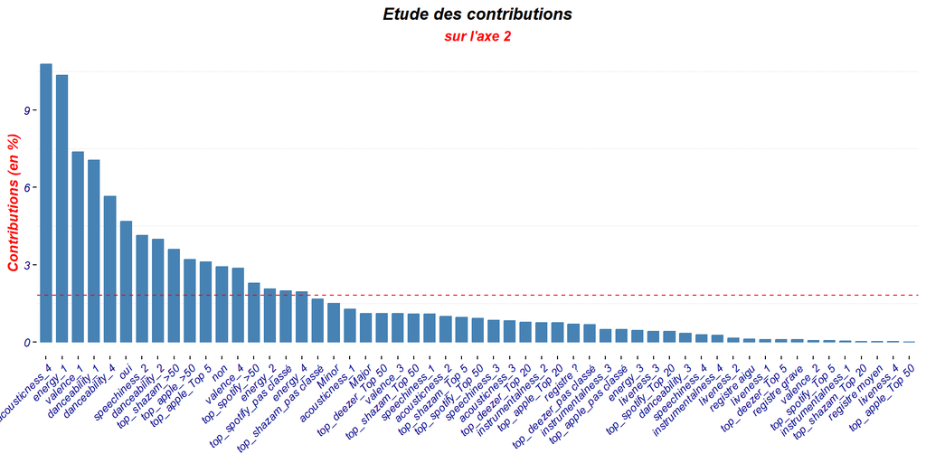

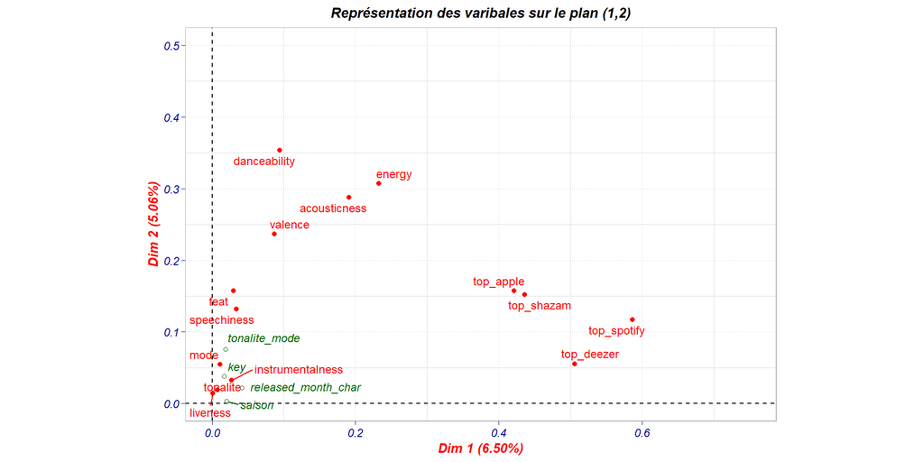

## Etude des individus :

- top_spotify
- Acousticness
- Energy
- Individus distants axe 1
- Individus distants axe 2
- Contribution
- 50% de contribution

[interactive chart not shown]

**Individu les plus distants sur l’Axe 1**

```
[1] 38
```

|  | Dim 1 | feat | released_year | released_month_char | saison | released_day | in_spotify_playlists | in_apple_playlists | in_deezer_playlists | bpm | tonalite | mode | top_spotify | top_apple | top_deezer | top_shazam | streams_normx100 | danceability | valence | energy | acousticness | instrumentalness | liveness | speechiness |
| --- | --- | --- | --- | --- | --- | --- | --- | --- | --- | --- | --- | --- | --- | --- | --- | --- | --- | --- | --- | --- | --- | --- | --- | --- |
| 1 | -0.93 | oui | 2017 | novembre | automne | 10 | 21097 | 384 | 1034 | 116 | registre grave | Major | &gt;50 | &gt;50 | Top 50 | &gt;50 | 43.3179 | 4 | 4 | 4 | 1 | 1 | 1 | 1 |
| 2 | -0.92 | oui | 2023 | juin | été | 29 | 859 | 35 | 41 | 122 | registre moyen | Minor | Top 50 | &gt;50 | Top 20 | &gt;50 | 1.6173 | 4 | 4 | 3 | 1 | 1 | 3 | 1 |
| 3 | -0.91 | oui | 2023 | mars | printemps | 16 | 3090 | 34 | 43 | 148 | registre moyen | Minor | Top 50 | &gt;50 | Top 20 | &gt;50 | 19.5708 | 3 | 4 | 4 | 2 | 1 | 1 | 1 |
| 4 | 1.22 | non | 2022 | mai | printemps | 13 | 1493 | 2 | 10 | 170 | registre grave | Minor | pas classé | pas classé | pas classé | pas classé | 1.1106 | 1 | 1 | 1 | 4 | 1 | 1 | 1 |
| 5 | 1.2 | non | 2011 | octobre | automne | 14 | 12353 | 35 | 549 | 93 | registre moyen | Major | pas classé | pas classé | pas classé | pas classé | 21.7742 | 1 | 2 | 1 | 4 | 1 | 2 | 1 |
| 6 | 1.16 | non | 2000 | juillet | été | 10 | 10826 | 24 | 805 | 103 | registre grave | Major | Top 5 | pas classé | pas classé | pas classé | 16.8192 | 1 | 1 | 1 | 4 | 1 | 1 | 1 |

**Individu les plus distants sur l’Axe 2**

|  | Dim 2 | feat | released_year | released_month_char | saison | released_day | in_spotify_playlists | in_apple_playlists | in_deezer_playlists | bpm | tonalite | mode | top_spotify | top_apple | top_deezer | top_shazam | streams_normx100 | danceability | valence | energy | acousticness | instrumentalness | liveness | speechiness |
| --- | --- | --- | --- | --- | --- | --- | --- | --- | --- | --- | --- | --- | --- | --- | --- | --- | --- | --- | --- | --- | --- | --- | --- | --- |
| 1 | -0.85 | oui | 2022 | janvier | hiver | 7 | 620 | 17 | 3 | 115 | registre moyen | Minor | pas classé | Top 5 | pas classé | pas classé | 1.4469 | 4 | 4 | 3 | 1 | 1 | 1 | 2 |
| 2 | -0.78 | oui | 2021 | novembre | automne | 30 | 648 | 14 | 81 | 133 | registre moyen | Minor | Top 5 | Top 5 | pas classé | pas classé | 6.4637 | 4 | 3 | 3 | 2 | 1 | 1 | 2 |
| 3 | -0.77 | oui | 2022 | janvier | hiver | 14 | 1034 | 19 | 12 | 174 | registre moyen | Minor | Top 5 | Top 5 | pas classé | pas classé | 6.591 | 3 | 4 | 4 | 2 | 1 | 1 | 2 |
| 4 | 1.79 | non | 2023 | juillet | été | 13 | 873 | 80 | 95 | 78 | registre ? | Major | &gt;50 | &gt;50 | Top 50 | &gt;50 | 0.7882 | 2 | 1 | 1 | 4 | 1 | 1 | 1 |
| 5 | 1.39 | oui | 2017 | août | été | 11 | 15032 | 221 | 1078 | 115 | registre moyen | Minor | Top 50 | &gt;50 | Top 5 | &gt;50 | 63.5877 | 1 | 1 | 1 | 4 | 1 | 1 | 1 |
| 6 | 1.39 | non | 2022 | octobre | automne | 28 | 3311 | 129 | 212 | 177 | registre aigu | Major | pas classé | Top 50 | Top 5 | Top 50 | 7.9936 | 1 | 1 | 1 | 4 | 1 | 1 | 1 |

|  | Musique | Dim 1 | Musique | Dim 2 |
| --- | --- | --- | --- | --- |
| 1 | Crown _ Kendrick Lamar | 0.82 | What Was I Made For? [From The Motion Picture "Barbie"] _ Billie Eilish | 2.28 |
| 2 | It's Beginning To Look A Lot Like Christmas _ Michael Bublï¿ | 0.79 | lovely - Bonus Track _ Billie Eilish, Khalid | 1.37 |
| 3 | Sparks _ Coldplay | 0.75 | Lift Me Up - From Black Panther: Wakanda Forever - Music From and Inspired By _ Rihanna | 1.37 |
| 4 | Phantom Regret by Jim _ The Weeknd | 0.67 | TV _ Billie Eilish | 1.37 |
| 5 | Bigger Than The Whole Sky _ Taylor Swift | 0.67 | Something In The Way - Remastered 2021 _ Nirvana | 1.34 |
| 6 | Sweet Nothing _ Taylor Swift | 0.66 | Nobody Gets Me _ SZA | 1.25 |

| dim 1 | dim 2 |
| --- | --- |
| 140 | 97 |

# Classification :

## Détermination du nombre de classe optimale

- Inertie
- CAH

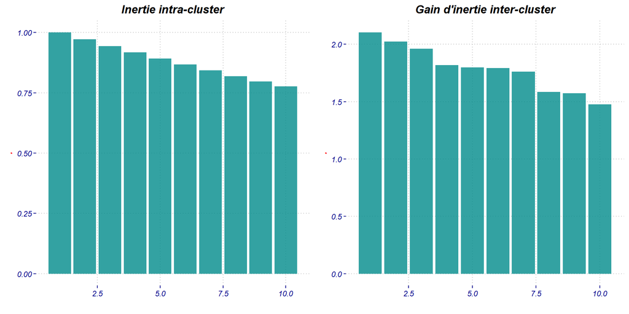

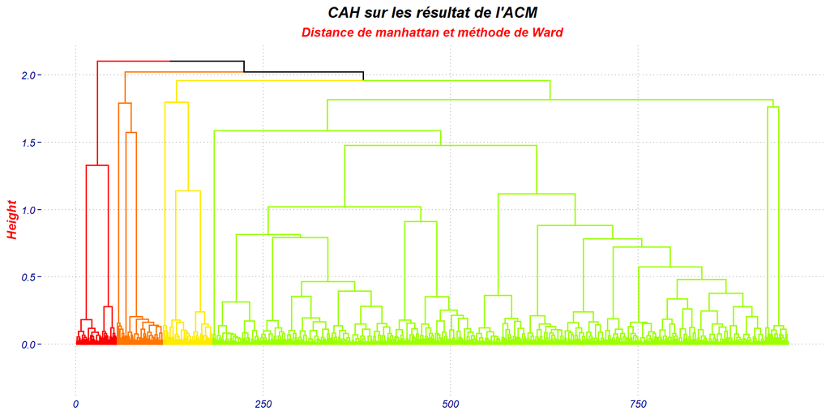

## Visualisation des clusters :

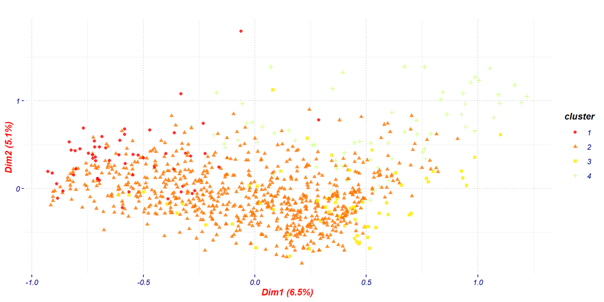

## Résulats de la classification (variables)

## Modalités représentatives

**Catégories représentant le mieux le premier cluster**

|  | Cla/Mod | Mod/Cla | Global | p.value | v.test |
| --- | --- | --- | --- | --- | --- |
| top_spotify=top_spotify_&gt;50 | 100 | 81.81818181818183 | 4.736842105263158 | 1.014315124760548e-67 | 17.38816413324317 |
| top_deezer=top_deezer_Top 50 | 100 | 38.18181818181819 | 2.210526315789473 | 1.577685442598756e-28 | 11.07949006314541 |
| top_apple=top_apple_&gt;50 | 11.53846153846154 | 87.27272727272727 | 43.78947368421053 | 7.533205245980986e-12 | 6.847156959118951 |
| top_shazam=top_shazam_&gt;50 | 16.41025641025641 | 58.18181818181818 | 20.52631578947368 | 3.017720895513446e-10 | 6.297865544629156 |
| top_deezer=top_deezer_Top 20 | 14.16666666666667 | 30.90909090909091 | 12.63157894736842 | 0.0002341138293909116 | 3.679039696419234 |
| key=C# | 10.83333333333333 | 23.63636363636364 | 12.63157894736842 | 0.02048671955647448 | 2.317312413966279 |
| tonalite=registre grave | 8.547008547008547 | 36.36363636363637 | 24.63157894736842 | 0.04598251440929787 | 1.99555378318971 |
| speechiness=speechiness_3 | 0 | 0 | 5.36842105263158 | 0.04384171703773872 | -2.015600981839185 |
| top_apple=top_apple_Top 50 | 2.5 | 7.272727272727272 | 16.84210526315789 | 0.0401124312608199 | -2.05258924751422 |
| danceability=danceability_1 | 0 | 0 | 5.578947368421053 | 0.03863861471743509 | -2.068014977652649 |

[output cut: 9 more lines]

**Catégories représentant le mieux le second cluster**

|  | Cla/Mod | Mod/Cla | Global | p.value | v.test |
| --- | --- | --- | --- | --- | --- |
| speechiness=speechiness_1 | 84.41890166028098 | 86.40522875816994 | 82.42105263157895 | 8.477527343224185e-10 | 6.135718281697589 |
| danceability=danceability_3 | 88.48039215686273 | 47.18954248366013 | 42.94736842105264 | 4.424374664263054e-08 | 5.473017073818454 |
| instrumentalness=instrumentalness_1 | 81.66127292340884 | 98.95424836601308 | 97.57894736842105 | 1.670363649385348e-06 | 4.789693368128826 |
| top_spotify=top_spotify_Top 50 | 92.10526315789474 | 18.30065359477124 | 16 | 2.364590064262906e-05 | 4.227350666088023 |
| valence=valence_4 | 89.60396039603961 | 23.66013071895425 | 21.26315789473684 | 0.0001201778894921544 | 3.845762984610535 |
| speechiness=speechiness_2 | 92.03539823008849 | 13.59477124183007 | 11.89473684210526 | 0.0004089816428820246 | 3.534219266086025 |
| energy=energy_4 | 86.17021276595744 | 31.76470588235294 | 29.68421052631579 | 0.003652273515118906 | 2.906730804742853 |
| acousticness=acousticness_1 | 83.66606170598911 | 60.26143790849673 | 57.99999999999999 | 0.004384999491026175 | 2.849049954082183 |
| key=F# | 91.78082191780823 | 8.758169934640522 | 7.684210526315789 | 0.007148918653686786 | 2.689826451472627 |
| tonalite=registre moyen | 85.3125 | 35.68627450980392 | 33.68421052631579 | 0.007212960894831014 | 2.686848736655675 |

[output cut: 17 more lines]

**Catégories représentant le mieux le troisième cluster**

|  | Cla/Mod | Mod/Cla | Global | p.value | v.test |
| --- | --- | --- | --- | --- | --- |
| speechiness=speechiness_3 | 100 | 82.25806451612904 | 5.36842105263158 | 4.229775147103935e-74 | 18.21089474564252 |
| instrumentalness=instrumentalness_2 | 72.72727272727273 | 12.90322580645161 | 1.157894736842105 | 3.045161528211539e-08 | 5.538820155991739 |
| speechiness=speechiness_4 | 100 | 4.838709677419355 | 0.3157894736842105 | 0.0002655061711581108 | 3.646819616500224 |
| energy=energy_2 | 12.56544502617801 | 38.70967741935484 | 20.10526315789474 | 0.0004884701153381172 | 3.48700068006456 |
| acousticness=acousticness_4 | 15.73033707865168 | 22.58064516129032 | 9.368421052631579 | 0.001276888263370242 | 3.221124139722111 |
| top_apple=top_apple_Top 5 | 13.04347826086956 | 24.19354838709678 | 12.10526315789474 | 0.006299432174086385 | 2.731774074629722 |
| top_deezer=top_deezer_pas classé | 8.258527827648116 | 74.19354838709677 | 58.63157894736842 | 0.009116903240114223 | 2.607639054092387 |
| top_spotify=top_spotify_pas classé | 8.91089108910891 | 58.06451612903226 | 42.52631578947368 | 0.01163296631230832 | 2.523086859941037 |
| tonalite=registre grave | 9.82905982905983 | 37.09677419354838 | 24.63157894736842 | 0.02413858081137516 | 2.254916334724204 |
| top_apple=top_apple_pas classé | 12.12121212121212 | 19.35483870967742 | 10.42105263157895 | 0.02921795484870274 | 2.180533278060429 |

[output cut: 13 more lines]

**Catégories représentant le mieux le quatrième cluster**

|  | Cla/Mod | Mod/Cla | Global | p.value | v.test |
| --- | --- | --- | --- | --- | --- |
| danceability=danceability_1 | 100 | 77.94117647058823 | 5.578947368421053 | 1.260372418384733e-73 | 18.15102056747003 |
| energy=energy_1 | 93.54838709677419 | 42.64705882352941 | 3.263157894736842 | 3.554559350393614e-34 | 12.18906969935703 |
| acousticness=acousticness_4 | 33.70786516853933 | 44.11764705882353 | 9.368421052631579 | 1.431763450981468e-15 | 7.982691574653195 |
| valence=valence_1 | 18.94736842105263 | 52.94117647058824 | 20 | 3.454040566311165e-10 | 6.276893699183393 |
| feat=non | 9.572649572649574 | 82.35294117647058 | 61.57894736842105 | 0.0001451893969500126 | 3.799156492279916 |
| top_deezer=top_deezer_pas classé | 9.515260323159785 | 77.94117647058823 | 58.63157894736842 | 0.0005862862775926317 | 3.437880543272626 |
| speechiness=speechiness_1 | 8.301404853128991 | 95.58823529411765 | 82.42105263157895 | 0.001025997089325907 | 3.28329919865603 |
| top_spotify=top_spotify_pas classé | 9.653465346534654 | 57.35294117647059 | 42.52631578947368 | 0.01134929159539242 | 2.531756064537702 |
| released_month_char=octobre | 15.06849315068493 | 16.17647058823529 | 7.684210526315789 | 0.01483407296122837 | 2.436404815573423 |
| key=A | 14.86486486486486 | 16.17647058823529 | 7.789473684210527 | 0.01649843024948138 | 2.397698694242639 |

[output cut: 21 more lines]

## Variables caractérisant la partition

|  | p-value | ddl |
| --- | --- | --- |
| speechiness | 7.047447665097821e-172 | 9 |
| top_spotify | 3.649651226436122e-161 | 12 |
| danceability | 7.980219791008126e-153 | 9 |
| top_deezer | 1.236926078812566e-80 | 9 |
| energy | 7.600159337361704e-76 | 9 |
| acousticness | 1.030571131837149e-22 | 9 |
| instrumentalness | 2.389738716708848e-18 | 9 |
| valence | 9.133225577736259e-12 | 9 |
| top_apple | 6.970929775292972e-10 | 12 |
| top_shazam | 6.196075956930826e-09 | 12 |

[output cut: 4 more lines]